# Diplomado en Inteligencia Artificial y Aprendizaje Profundo

# Introducción a Keras Sequential y API Funcional

## Profesores

1. Alvaro Mauricio Montenegro Díaz, ammontenegrod@unal.edu.co
2. Daniel Mauricio Montenegro Reyes, dextronomo@gmail.com
3. Campo Elías Pardo Turriago, cepardot@unal.edu.co

## Asesora Medios y Marketing digital

1. Maria del Pilar Montenegro, pmontenegro88@gmail.com

## Asistentes

1. Oleg Jarma, ojarmam@unal.edu.co
2. Laura Lizarazo, ljlizarazore@unal.edu.co

## Contenido

- Introducción a TensorFlow
- Introducción a Keras
- ¿Por qué elegir Keras?
- Simulando Datos
- Visualizando Datos
- Construyendo Red Neuronal (Diseño))
- Compilando Red Neuronal (Forma de Optimizar))
- Entrenando Red Neuronal)
- Visualizar Resultados de la Red
- Redes Neuronales

## Introducción a TensorFlow

La mejor introducción a esta biblioteca fundamental de inteligencia artificial es entrando a la documentación oficial:

[figure not shown]

[Volver]

## Introducción a Keras

Keras no es más que una API funcionando sobre algún motor tensorial (Por ejemplo, **TensorFlow**).

Igual que antes, no hay nada mejor que ir a los sitios oficiales y chequear por sí mismxs la documentación oficial:

[Volver]

## ¿Por qué elegir Keras?

Preguntémosle a dios Google:

[figure not shown]

[Volver]

# Importando Librerías Necesarias

Como siempre, lo primero que debemos hacer es importar las librerías necesarias:

```python
# Librería para manejo de tensores
import tensorflow as tf
# API para AI sobre motor de tensores
from tensorflow import keras
# Manejo de arreglos
import numpy as np
# Dibujitos
import matplotlib.pyplot as plt
```

[Volver]

# Simulando Datos

En esta ocasión y por ser la introducción, mostraremos que el proceso de optimización visto en clase (usando JAX), es equivalente a construir una red neuronal artificial.

Para esto, simulemos unos datos de prueba:

```python
# Genera datos espaciados uniformemente
x=np.linspace(-10,10,50)
# Modelo generado a partir de las entradas
y=2*x**2+3*x+5*np.random.normal(0,4,size=len(x))
```

Observemos algo de los datos simulados:

```python
print(x)
```

```
[-10.          -9.59183673  -9.18367347  -8.7755102   -8.36734694
  -7.95918367  -7.55102041  -7.14285714  -6.73469388  -6.32653061
  -5.91836735  -5.51020408  -5.10204082  -4.69387755  -4.28571429
  -3.87755102  -3.46938776  -3.06122449  -2.65306122  -2.24489796
  -1.83673469  -1.42857143  -1.02040816  -0.6122449   -0.20408163
   0.20408163   0.6122449    1.02040816   1.42857143   1.83673469
   2.24489796   2.65306122   3.06122449   3.46938776   3.87755102
   4.28571429   4.69387755   5.10204082   5.51020408   5.91836735
   6.32653061   6.73469388   7.14285714   7.55102041   7.95918367
   8.36734694   8.7755102    9.18367347   9.59183673  10.        ]
```

```python
print(y)
```

```
[194.4545927  192.80883855 141.01243391 114.38238015 118.04930055
  89.94240509 106.63384989  48.91404792  59.22915388  80.89181462
  69.47695736 107.87735096   5.35364441  27.29934736  16.45808647
 -18.18922843  11.89906512 -42.95704948   8.69746531 -48.77450645
  20.71615519 -32.46368686   1.70807651 -10.44188169 -13.25159922
   0.47286081 -21.52376028   8.34941391 -20.14152154   8.70987567
  41.71664612  41.35947064  66.51779667  37.47563888   5.61354701
  67.84734202  34.06762653  42.24266409  29.55810679  83.83583516
  66.49709929  75.87418716 107.73342703 135.76750977 165.95167544
 167.77816217 161.84487332 213.40145707 257.95833962 246.49705112]
```

[Volver]

# Visualizando Datos

En lo posible, trate de visualizar datos para tener una intuición sobre lo que está pasando. Es claro que no siempre es posible hacerlo, pero exsiten, por ejemplo, técnicas de reducción de dimensión para dar una idea vaga de lo que está pasando.

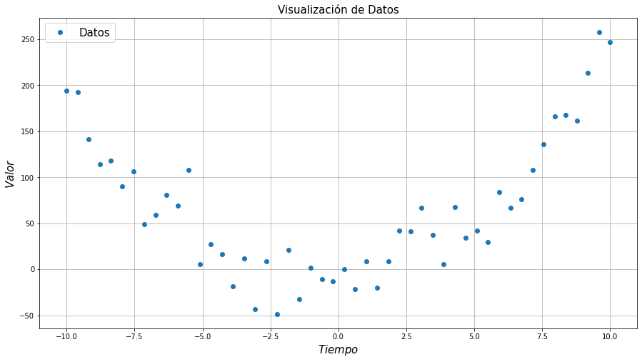

```python
# Generar Lienzo
plt.figure(figsize=(15,8))
#Titulo del lienzo
plt.title("Visualización de Datos",fontsize=15)
#Dibujar datos
plt.plot(x,y,'o')
# Leyenda de los datos
plt.legend(["Datos"],fontsize=15)
# Nombrar Ejes
plt.xlabel("$Tiempo$",fontsize=15)
plt.ylabel("$Valor$",fontsize=15)

# Poner cuadrícula
plt.grid()
# Mostrar imagen
plt.show()
```

[Volver]

# Construyendo Red Neuronal (Diseño)

Para construir nuestra primera red Neuronal, recuerde el siguiente dibujo:

[figure not shown]

Vemos que el dibujo opera de izquierda a derecha ($\rightarrow$), por lo que tiene sentido llamarlo **Modelo Secuencial**.

En este caso, usaremos una neurona (`units`) y la dimensión de entrada es unidimensional (`input_shape`)

```python
model = keras.Sequential(
    keras.layers.Dense(units=1,input_shape=(1,))
    )
```

[Volver]

# Compilando Red Neuronal (Forma de Optimizar)

Ahora que tenemos nuestra maqueta de las ecuaciones del modelo, elegimos una función de pérdida adecuada a nuestro problema y un optimizador para minimizar dicha pérdida:

```python
model.compile(optimizer='sgd', loss='mean_squared_error')
```

[Volver]

# Resumen de la Red Neuronal

El modelo creado y compilado tiene muchos otros métodos interesantes.

Por ejemplo, podemos ver el resumen de lo que tiene la red.

```python
model.summary()
```

```
Model: "sequential"
_________________________________________________________________
Layer (type)                 Output Shape              Param #
=================================================================
dense (Dense)                (None, 1)                 2
=================================================================
Total params: 2
Trainable params: 2
Non-trainable params: 0
_________________________________________________________________
```

También es posible visualizar los modelos en forma de grafo, lo cual es muy útil para tener control global de la arquitectura del modelo:

```python
from tensorflow.keras.utils import plot_model
```

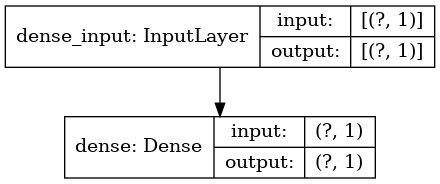

```python
plot_model(model,show_shapes=True)
```

[Volver]

# Entrenando Red Neuronal (Fancy para "Ajustar los datos")

```python
model.fit(x, y, epochs=10,verbose=1)
```

```
<tensorflow.python.keras.callbacks.History at 0x7fd924669a00>
```

[Volver]

# Visualizar Resultados de la Red

```python
#Obtener Pesos de la Red
w=model.get_weights();
print(w)
#Imprimir resultados
print("\nObjeto Pesos:",w)
print('\nNumber of Weights -> '+ str(len(w)))
print('\nw = ' + str(w[0][0]) +'(Weight)')
print('b = ' + str(w[1])+'("Weight"->Bias)')
```

```
[array([[4.3438725]], dtype=float32), array([21.641872], dtype=float32)]

Objeto Pesos: [array([[4.3438725]], dtype=float32), array([21.641872], dtype=float32)]

Number of Weights -> 2

w = [4.3438725](Weight)
b = [21.641872]("Weight"->Bias)
```

[Volver]

# Predecir valores dentro de los datos (Ver Regresión)

```python
predecir=model.predict(x)
#print(predecir)
#np.vstack((predecir.reshape(-1,),y)).T
```

[Volver]

# Visualizar Resultados

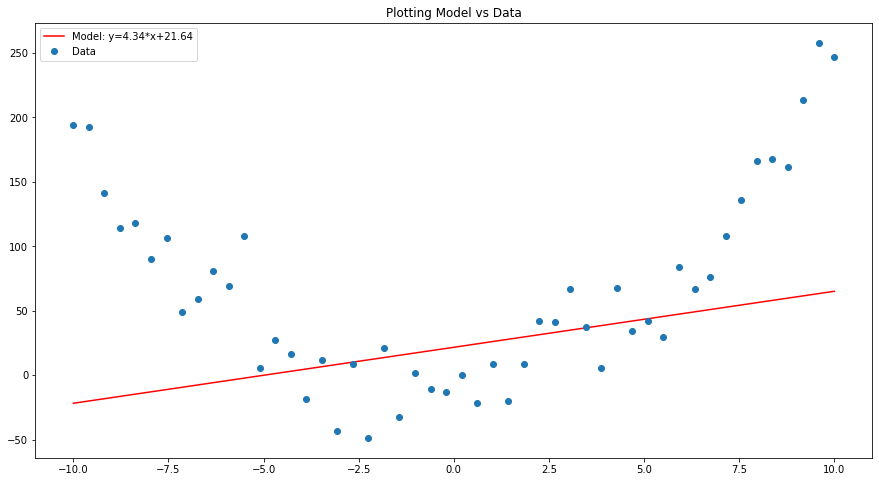

```python
plt.figure(figsize=(15,8))
plt.plot(x,predecir,'r-',label='Model: y={:.2f}*x+{:.2f}'.format(w[0].item(),w[1].item()))
plt.plot(x,y,'o', label='Data')
plt.title('Plotting Model vs Data')
plt.legend(loc=0)
plt.show()
```

[Volver]

# Mejorando Red Neuronal

```python
model2 = tf.keras.Sequential([
    keras.layers.Dense(units=5,input_shape=(1,),activation='softplus'),
    keras.layers.Dense(units=10,activation='softplus'),
    keras.layers.Dense(units=20,activation='softplus'),
    keras.layers.Dense(units=1),
    ])
model2.compile(optimizer='adam', loss='mean_squared_error')
model2.summary()
```

```
Model: "sequential_1"
_________________________________________________________________
Layer (type)                 Output Shape              Param #
=================================================================
dense_1 (Dense)              (None, 5)                 10
_________________________________________________________________
dense_2 (Dense)              (None, 10)                60
_________________________________________________________________
dense_3 (Dense)              (None, 20)                220
_________________________________________________________________
dense_4 (Dense)              (None, 1)                 21
=================================================================
Total params: 311
Trainable params: 311
Non-trainable params: 0
_________________________________________________________________
```

```python
history=model2.fit(x, y, epochs=1000,verbose=0)
```

```python
#Obtener Pesos de la Red
w2=model2.get_weights();
#Imprimir resultados
#print("\nObjeto Pesos:",w2)
#print('\nNumber of Weights -> '+ str(len(w2)))
#print('\nw = ' + str(w[0][0]) +'(Weight)')
#print('b = ' + str(w[1])+'("Weight"->Bias)')
```

```python
x_test=np.linspace(x[0],x[-1],300)
predecir=model2.predict(x_test)
```

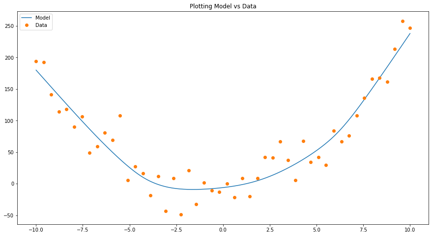

```python
plt.figure(figsize=(15,8))
plt.plot(x_test,predecir,label='Model')
plt.plot(x,y,'o', label='Data')
plt.title('Plotting Model vs Data')
plt.legend(loc=0)
plt.show()
```

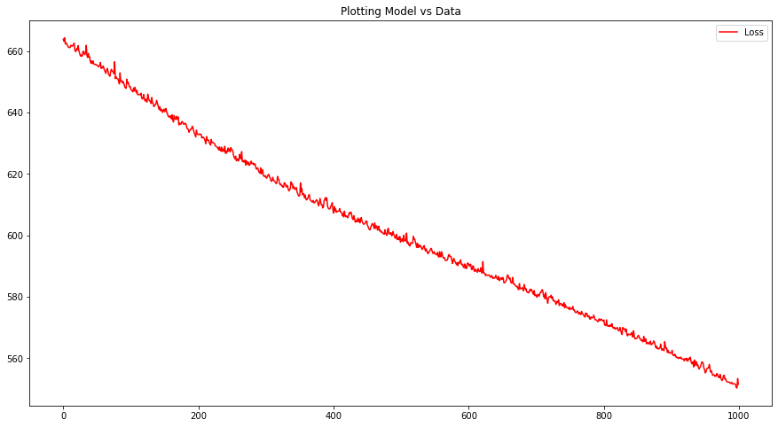

```python
plt.figure(figsize=(15,8))
plt.plot(history.history['loss'],'r-',label='Loss')
plt.title('Plotting Model vs Data')
plt.legend(loc=0)
plt.show()
```

# **Datos más Retadores**

```python
trend=0.1
time=np.arange(0,100,0.1)
y=trend*time+np.sin(time)+np.random.normal(scale=0.5,size=len(time))
```

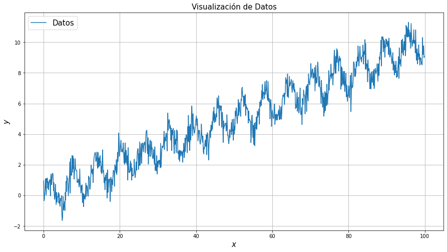

```python
plt.figure(figsize=(15,8))
plt.title("Visualización de Datos",fontsize=15)
plt.plot(time,y,'-')
plt.legend(["Datos"],fontsize=15)
plt.xlabel("$x$",fontsize=15)
plt.ylabel("$y$",fontsize=15)
plt.grid()
plt.show()
```

```python
model3 = tf.keras.Sequential([
    keras.layers.Dense(units=10,input_shape=(1,),activation='elu'),
    keras.layers.Dense(units=20,activation='elu'),
    keras.layers.Dense(units=30,activation='elu'),
    keras.layers.Dense(units=40,activation='elu'),
    keras.layers.Dense(units=50,activation='elu'),
    keras.layers.Dense(units=60,activation='elu'),
    keras.layers.Dense(units=70,activation='elu'),
    keras.layers.Dense(units=1)
    ])

model3.compile(optimizer='adam', loss='mean_squared_error')
model3.summary()
```

```
Model: "sequential_2"
_________________________________________________________________
Layer (type)                 Output Shape              Param #
=================================================================
dense_5 (Dense)              (None, 10)                20
_________________________________________________________________
dense_6 (Dense)              (None, 20)                220
_________________________________________________________________
dense_7 (Dense)              (None, 30)                630
_________________________________________________________________
dense_8 (Dense)              (None, 40)                1240
_________________________________________________________________
dense_9 (Dense)              (None, 50)                2050
_________________________________________________________________
dense_10 (Dense)             (None, 60)                3060
_________________________________________________________________
dense_11 (Dense)             (None, 70)                4270
_________________________________________________________________
dense_12 (Dense)             (None, 1)                 71
=================================================================
Total params: 11,561
Trainable params: 11,561
Non-trainable params: 0
_________________________________________________________________
```

```python
history=model3.fit(time, y, epochs=10000,verbose=0)
```

```python
#Obtener Pesos de la Red
w3=model3.get_weights();
#Imprimir resultados
#print("\nObjeto Pesos:",w2)
#print('\nNumber of Weights -> '+ str(len(w2)))
#print('\nw = ' + str(w[0][0]) +'(Weight)')
#print('b = ' + str(w[1])+'("Weight"->Bias)')
```

```python
x_test=np.linspace(time[0],time[-1],3000)
predecir=model3.predict(x_test)
```

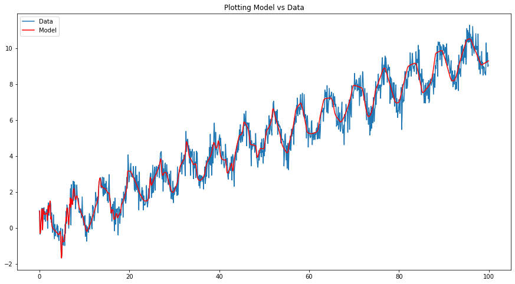

```python
plt.figure(figsize=(15,8))
plt.plot(time,y,'-', label='Data')
plt.plot(x_test,predecir,'r',label='Model')
plt.title('Plotting Model vs Data')
plt.legend(loc=0)
plt.show()
```

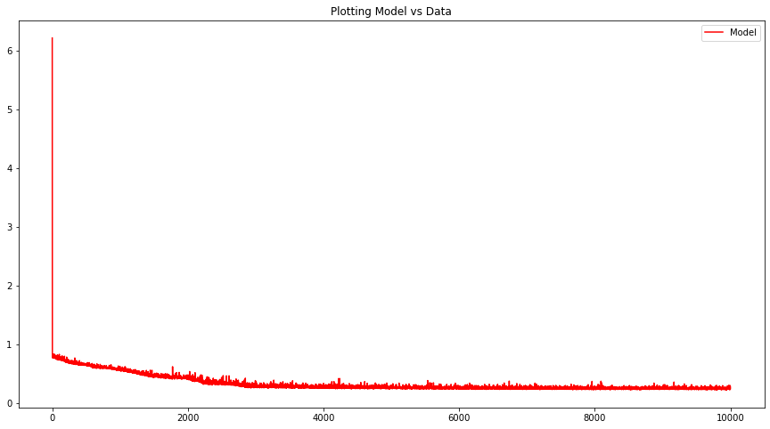

```python
plt.figure(figsize=(15,8))
plt.plot(history.history['loss'],'r-',label='Model')
plt.title('Plotting Model vs Data')
plt.legend(loc=0)
plt.show()
```

# **API Funcional**

```python
import tensorflow as tf
import numpy as np
import matplotlib.pyplot as plt
from tensorflow import keras
from tensorflow.keras.layers import Activation, Input,Dense
from tensorflow.keras.models import Model
from tensorflow.keras.optimizers import Adam
```

```python
trend=0.1
time=np.arange(0,100,0.1)
y=trend*time+np.sin(time)+np.random.normal(scale=0.5,size=len(time))
```

```python
inputs=Input(shape=(1,))
output=inputs
capas=10
dim=10
output=Activation('elu')(output)

for capa in range(capas):
    output=Dense(dim)(output)
    output=Activation('elu')(output)
    dim+=10
output=Dense(1)(output)

model=Model(inputs,output)
model.compile(loss='mse',optimizer='adam')
model.summary()
```

```
Model: "functional_1"
_________________________________________________________________
Layer (type)                 Output Shape              Param #
=================================================================
input_1 (InputLayer)         [(None, 1)]               0
_________________________________________________________________
activation (Activation)      (None, 1)                 0
_________________________________________________________________
dense_13 (Dense)             (None, 10)                20
_________________________________________________________________
activation_1 (Activation)    (None, 10)                0
_________________________________________________________________
dense_14 (Dense)             (None, 20)                220
_________________________________________________________________
activation_2 (Activation)    (None, 20)                0
_________________________________________________________________
dense_15 (Dense)             (None, 30)                630
_________________________________________________________________
activation_3 (Activation)    (None, 30)                0
_________________________________________________________________
dense_16 (Dense)             (None, 40)                1240
_________________________________________________________________
activation_4 (Activation)    (None, 40)                0
_________________________________________________________________
dense_17 (Dense)             (None, 50)                2050
_________________________________________________________________
activation_5 (Activation)    (None, 50)                0
_________________________________________________________________
dense_18 (Dense)             (None, 60)                3060
_________________________________________________________________
activation_6 (Activation)    (None, 60)                0
_________________________________________________________________
dense_19 (Dense)             (None, 70)                4270
_________________________________________________________________
activation_7 (Activation)    (None, 70)                0
_________________________________________________________________
dense_20 (Dense)             (None, 80)                5680
_________________________________________________________________
activation_8 (Activation)    (None, 80)                0
_________________________________________________________________
dense_21 (Dense)             (None, 90)                7290
_________________________________________________________________
activation_9 (Activation)    (None, 90)                0
_________________________________________________________________
dense_22 (Dense)             (None, 100)               9100
_________________________________________________________________
activation_10 (Activation)   (None, 100)               0
_________________________________________________________________
dense_23 (Dense)             (None, 1)                 101
=================================================================
Total params: 33,661
Trainable params: 33,661
Non-trainable params: 0
_________________________________________________________________
```

```python
history=model.fit(time,y,epochs=500,verbose=0)
```

```python
x_test=np.linspace(time[0],time[-1],1000)
predecir=model.predict(x_test)
```

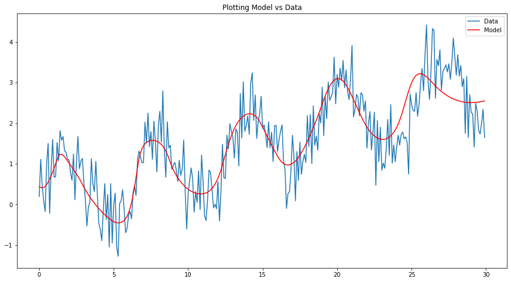

```python
plt.figure(figsize=(15,8))
plt.plot(time[0:300],y[0:300],'-', label='Data')
plt.plot(x_test[0:300],predecir[0:300],'r',label='Model')
plt.title('Plotting Model vs Data')
plt.legend(loc=0)
plt.show()
```

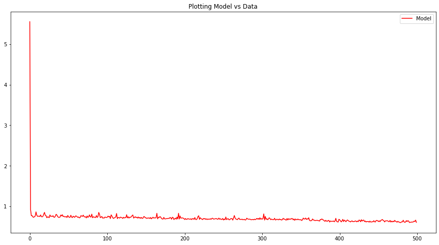

```python
plt.figure(figsize=(15,8))
plt.plot(history.history['loss'],'r-',label='Model')
plt.title('Plotting Model vs Data')
plt.legend(loc=0)
plt.show()
```